# Task 7 - Noah Christensen

# #1

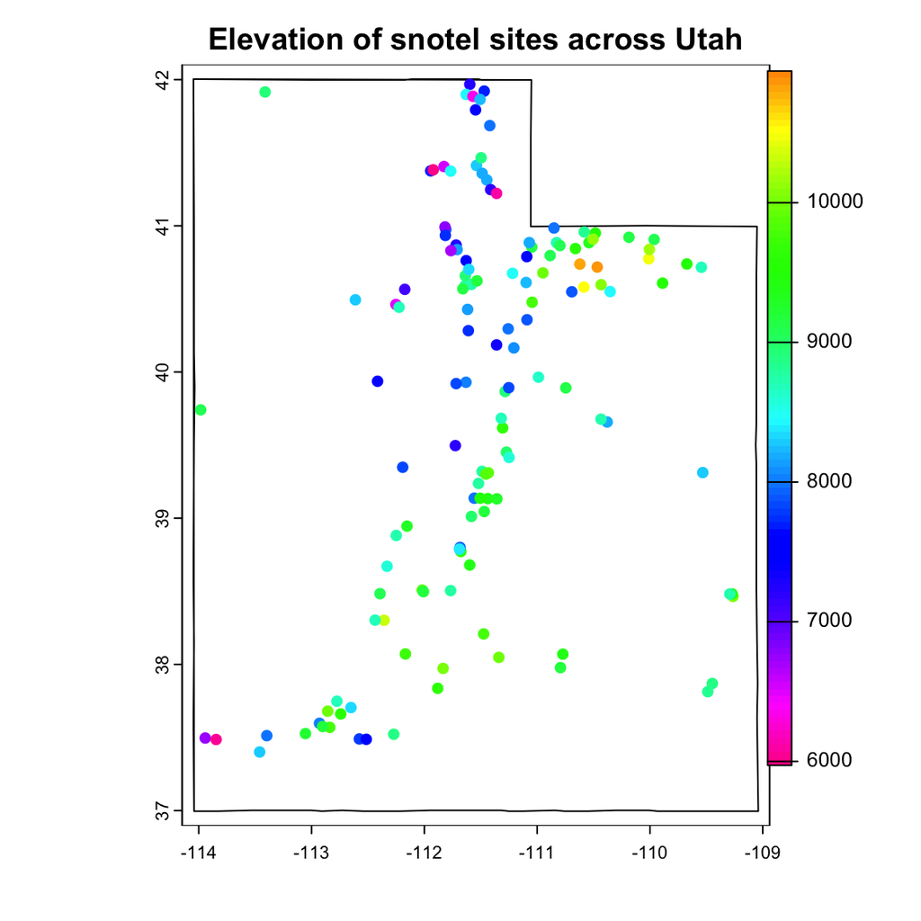

```r
# Reading in libraries
library(tidyverse)
library(terra)
library(RColorBrewer)
library(broom)
library(maps)

# Reading in Snotel Metadata
df <- read.csv("./UTSNTL_META.csv")

# Task 1
df_vect <- vect(df,geom=c("Longitude", "Latitude"))

UT_map = map("state", "Utah", plot = F) # save geometry
UT_shp = vect(cbind(UT_map$x, UT_map$y), type = "lines", crs= "+proj=longlat +datum=WGS84")

# Plotting snotel sites by elevation
plot(UT_shp, main = "Elevation of snotel sites across Utah")
plot(df_vect,"Elevation..ft.",type="continuous",add=T)
```

# #2

```r
# Reading in cleaned snow data from Task 6
df2 <- read.csv("./cleaned_snow.csv")

# Turning date column into date format
df2$Date <- as.Date(df2$Date)
df_2021_winter <- df2[df2$Date < "2022-03-21" & df2$Date > "2021-12-21",]

# Only keeping row with the highest snow depth
df_max_snow_depth <- filter(df_2021_winter, grepl("Snow_Depth", data)) %>%
  arrange(desc(Value)) %>%
  distinct(location, .keep_all = TRUE)

# Rename location column as Station.Name
df_max_snow_depth <- df_max_snow_depth %>%
  rename(Station.Name = location)

# Removing spaces, periods, and hyphens
df$Station.Name <- gsub(" ","_", df$Station.Name)
df$Station.Name <- gsub("\\.","_",df$Station.Name)
df$Station.Name <- gsub("-","_",df$Station.Name)


# Arranging the names in alphabetical order so its easier to see the differences
df_max_snow_depth <- df_max_snow_depth %>% arrange(Station.Name)

# Finding columns that don't match
not_matching_df_max <- which(is.na(match(df_max_snow_depth$Station.Name,df$Station.Name)))
not_matching_df <- which(is.na(match(df$Station.Name,df_max_snow_depth$Station.Name)))

# Looking at names that don't match
df[not_matching_df,]
```

```
##     Longitude Latitude   Station.Name Elevation..ft.
## 26  -111.0477 40.85464 Chalk_Creek_#1           9171
## 27  -111.0695 40.88529 Chalk_Creek_#2           8208
## 30  -111.2836 39.86671 Clear_Creek_#1           8975
## 31  -111.2515 39.89275 Clear_Creek_#2           7837
## 70  -110.4332 40.59709    Lakefork_#1          10128
## 71  -110.3529 40.55020    Lakefork_#3           8464
## 91  -109.8881 40.60798     Mosby_Mtn_           9553
## 99  -111.6311 39.92976    Payson_R_S_           8044
## 132 -110.9885 39.96450 White_River_#1           8641
## 133 -111.8816 37.83633     Widtsoe_#3           9640
```

```r
df_max_snow_depth[not_matching_df_max,]
```

```
##          X       Date Value   season                                data
## 26  374984 2021-12-31    58 season_2 Snow_Depth__in__Start_of_Day_Values
## 29  431726 2022-03-10    48 season_2 Snow_Depth__in__Start_of_Day_Values
## 68  375248 2021-12-31    35 season_2 Snow_Depth__in__Start_of_Day_Values
## 88  429626 2022-03-07    54 season_2 Snow_Depth__in__Start_of_Day_Values
## 96  432140 2022-03-10    43 season_2 Snow_Depth__in__Start_of_Day_Values
## 129 432338 2022-03-10    38 season_2 Snow_Depth__in__Start_of_Day_Values
## 130 420836 2022-02-24    40 season_2 Snow_Depth__in__Start_of_Day_Values
##     Station.Name
## 26   Chalk_Creek
## 29   Clear_Creek
## 68      Lakefork
## 88     Mosby_Mtn
## 96    Payson_R_S
## 129  White_River
## 130      Widtsoe
```

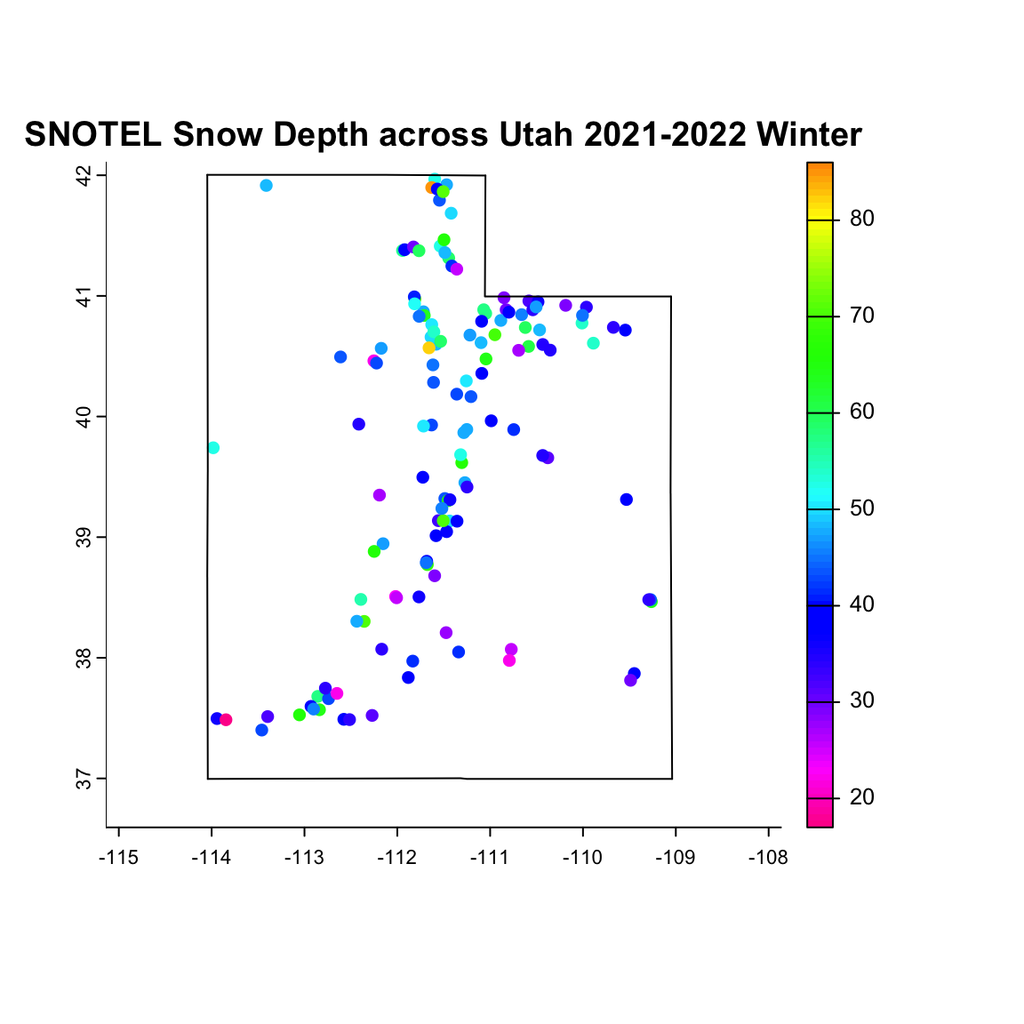

```r
# Fixing columns one by one
df$Station.Name <- gsub("Chalk_Creek_#1","Chalk_Creek",df$Station.Name)
df$Station.Name <- gsub("Chalk_Creek_#2","Chalk_Creek",df$Station.Name)
df$Station.Name <- gsub("Clear_Creek_#1","Clear_Creek",df$Station.Name)
df$Station.Name <- gsub("Clear_Creek_#2","Clear_Creek",df$Station.Name)
df$Station.Name <- gsub("Lakefork_#1","Lakefork",df$Station.Name)
df$Station.Name <- gsub("Lakefork_#3","Lakefork",df$Station.Name)
df$Station.Name <- gsub("Mosby_Mtn_","Mosby_Mtn",df$Station.Name)
df$Station.Name <- gsub("White_River_#1","White_River",df$Station.Name)
df$Station.Name <- gsub("Widtsoe_#3","Widtsoe",df$Station.Name)
df$Station.Name <- gsub("Payson_R_S_","Payson_R_S",df$Station.Name)

# Full joining
df_full <- full_join(df,df_max_snow_depth, by = "Station.Name")

# Making full vector for the full join dataframe
vect_full <- vect(df_full,geom=c("Longitude","Latitude"))

# Plotting
plot(vect_full, "Value", type="continuous",box=F,buffer=T,xlim=c(-115,-108),ylim=c(36.7,42),
     main="SNOTEL Snow Depth across Utah 2021-2022 Winter")
library(maps)
map(database="state",regions = "Utah",add=T)
```

# #3

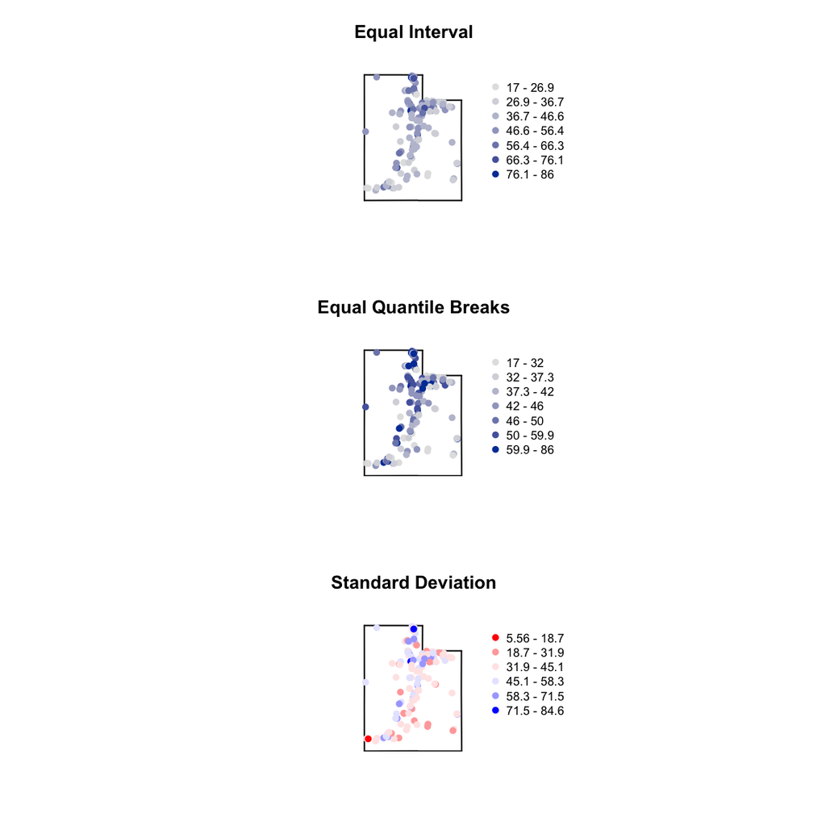

```r
par(mfrow = c(3,1), mar = c(0,3,4,3))

# Equal interval plots
map(database="state",regions = "Utah")
plot(vect_full,
     type = 'interval',
     breakby = "eqint",
     "Value",
     breaks = 7,
     col = rev(colorspace::sequential_hcl(7)),
     box=F,
     buffer=T,
     xlim=c(-115,-108),ylim=c(36.5,43),
     main= "Equal Interval",
     add=T)


# Quantile plots
map(database="state",regions = "Utah")
plot(vect_full,
     type = 'interval',
     breakby = "cases",
     "Value",
     breaks = 7,
     col = rev(colorspace::sequential_hcl(7)),
     box=F,
     buffer=T,
     xlim=c(-115,-108),ylim=c(36.5,43),
     main= "Equal Quantile Breaks",
     add=T)




# Standard deviation plots
snow_mean <- mean(vect_full$Value,na.rm=T)
snow_sd <- sd(vect_full$Value,na.rm=T)

breaks = c((snow_mean - 3*snow_sd),
            (snow_mean - 2*snow_sd),
           (snow_mean - snow_sd),
           snow_mean,
            (snow_mean + snow_sd),
           (snow_mean + 2*snow_sd),
           (snow_mean + 3*snow_sd))


map(database="state",regions = "Utah")
plot(vect_full,
     type = 'interval',
     "Value",
     breaks = breaks,
     col = rev(colorspace::diverge_hsv(6)),
     box=F,
     buffer=T,
     xlim=c(-115,-108),ylim=c(36.5,43),
     add=T,
     main = "Standard Deviation")
```

The equal interval, equal quantile, and standard deviation plots all give different insights into the data you are looking at. The Equal interval is like the name says it creates equal intervals from the max to min specified by the amount of breaks. This can be nice if you are comparing data that should have a linear trend. Equal Quantile breaks separates the data into sets of equal counts of data per break, this can be nice if you are wanting an even distribution of values in each break. Standard deviation breaks are nice when you want to view values above and below the mean and how far off they are from the expected values.

# #4

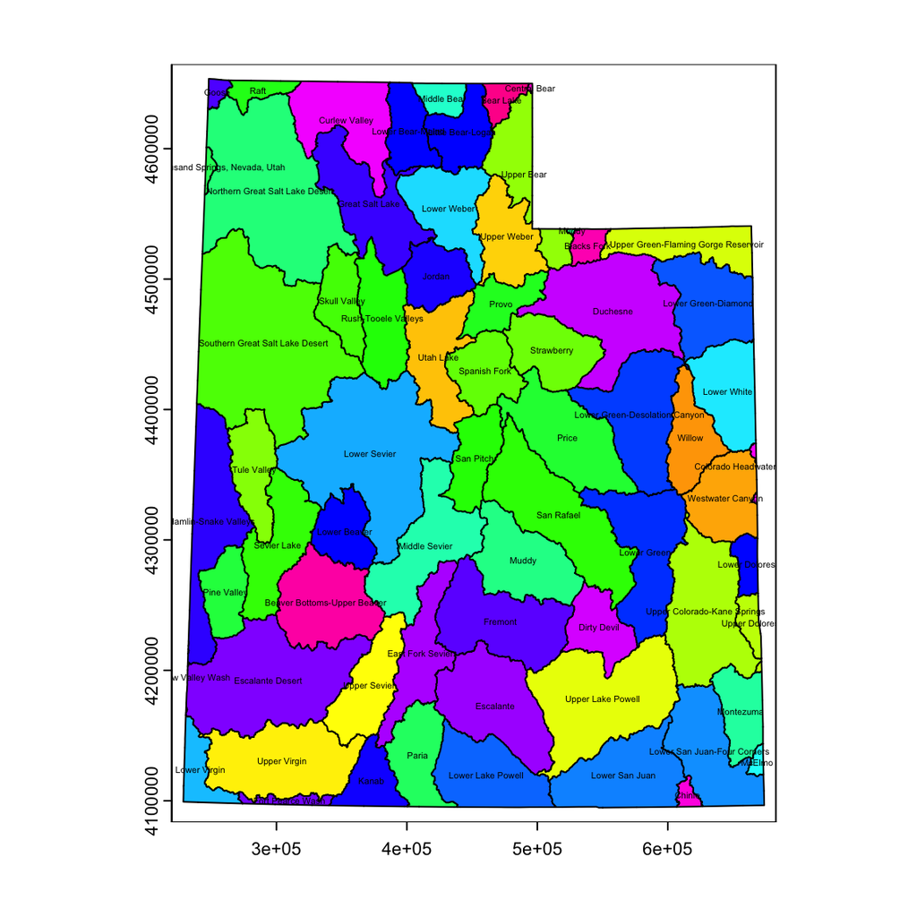

```r
# Reading in HUC vector
UT_shape <- vect("./UT_HUC8/UT_HUC8.shp")

# Setting parameter and margins
par(mfrow = c(1,1),mar = c(4,4,4,4))

# Plotting
plot(UT_shape,"NAME",legend = F)
text(UT_shape, "NAME", cex=0.35, col='black')
```

# #5

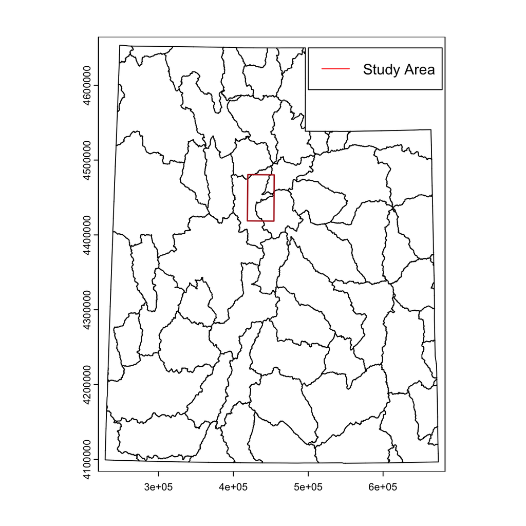

```r
# Creating extent object
extent <- as.polygons(ext(c(-111.952211,-111.536395,39.915063,40.471646)))

# Setting coordinate reference system for the extent
crs(extent) <- "epsg:4269"

# Projecting extent to UT_shape crs
extent <- project(extent,UT_shape)

# Plot the UT_shape
plot(UT_shape)

# Plot the extent
plot(extent, border = "firebrick", lwd = 1.5, add = TRUE)

# Add legend for extent
legend(x=500000,y=4650000,legend = "Study Area", lty=1,col="red")
```

# #6

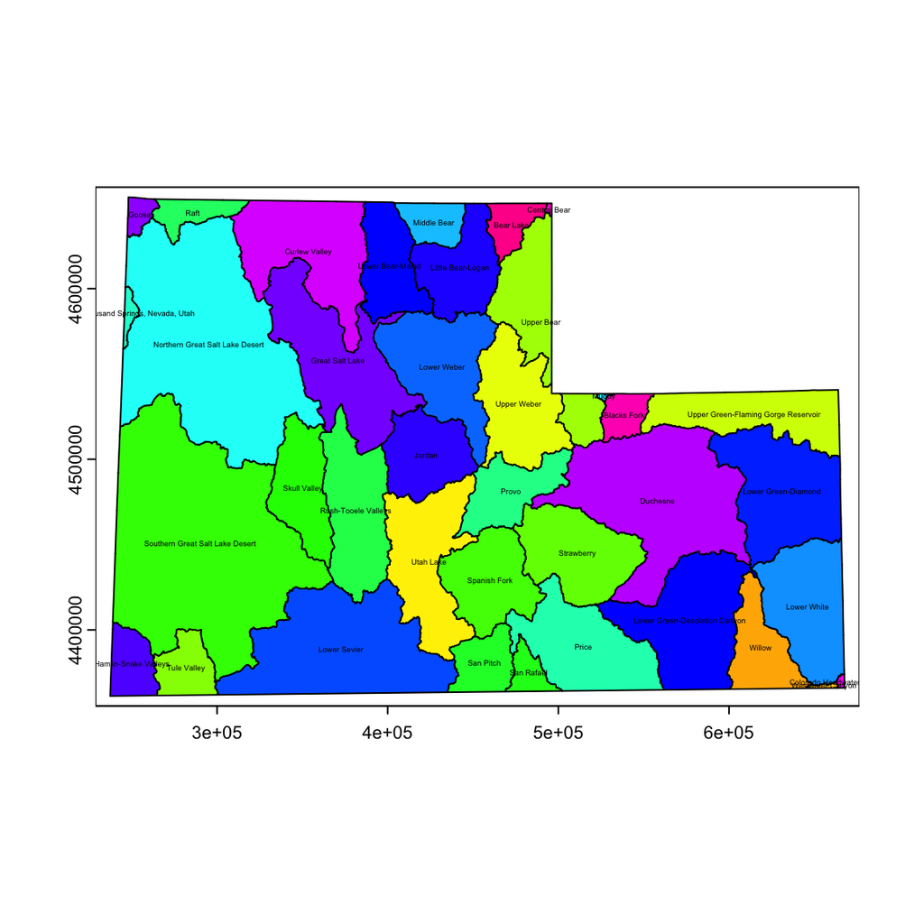

```r
# Creating polygon that encompasses Utah above 39 degrees latitude
above_39_lat <- as.polygons(ext(c(-120,-100,39,60)))

# Setting coordinate reference system for that extent
crs(above_39_lat) <- "epsg:4269"

# Projecting that coordinate reference system to the UT reference system
above_39_lat <- project(above_39_lat,UT_shape)

# Cropping the Utah by the extent made
crop_UT_shape <- crop(UT_shape,above_39_lat)

# Plotting
plot(crop_UT_shape, "NAME",legend = F)
text(crop_UT_shape,"NAME",cex = 0.3)
```

# #7

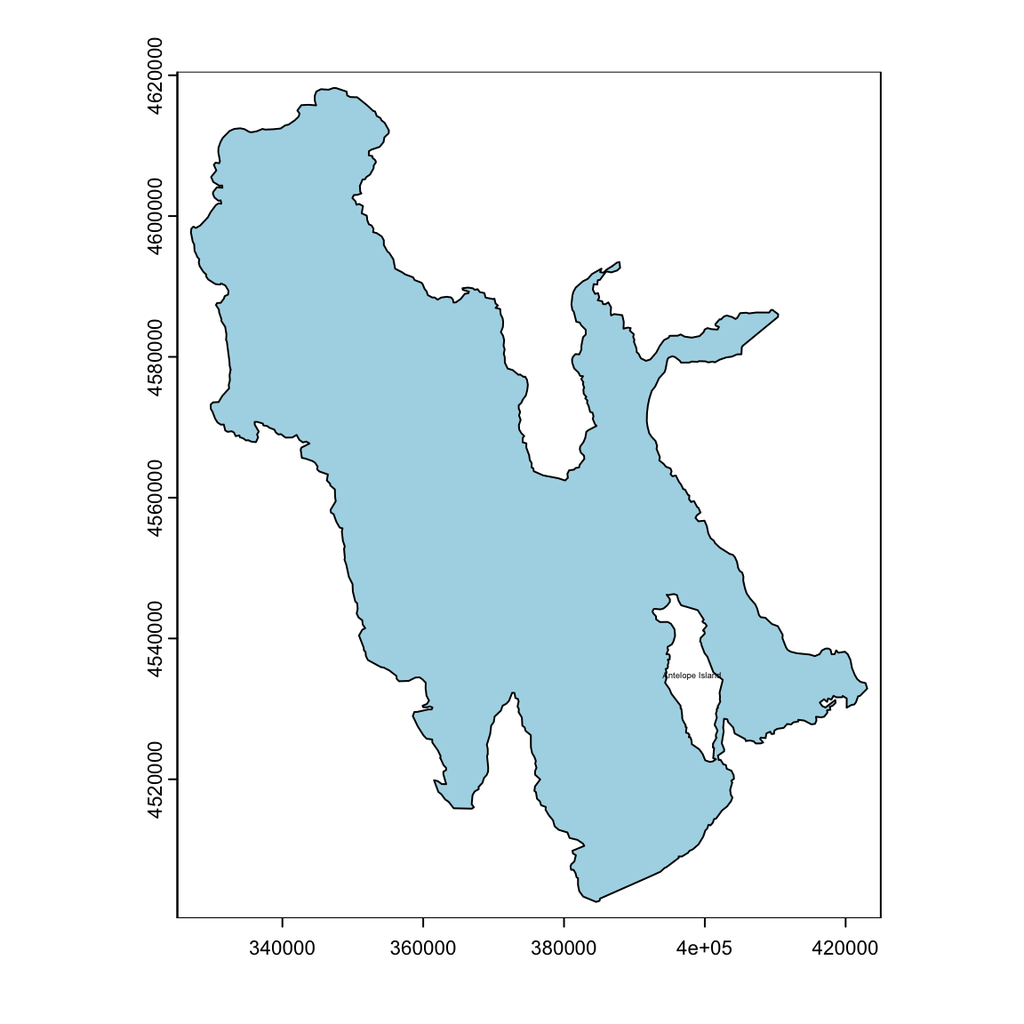

```r
# Reading in Antelope island
island <- vect("https://raw.githubusercontent.com/mattols/geospat_data/main/AntelopeIsland.geojson")

# Projecting antelope island to the UT CRS
island <- project(island,UT_shape)

# Plotting
plot(UT_shape[UT_shape$NAME == "Great Salt Lake"], col= "lightblue")
plot(island, add = T,col="white")
text(island, "Antelope Island", cex = 0.3)
```

# #8

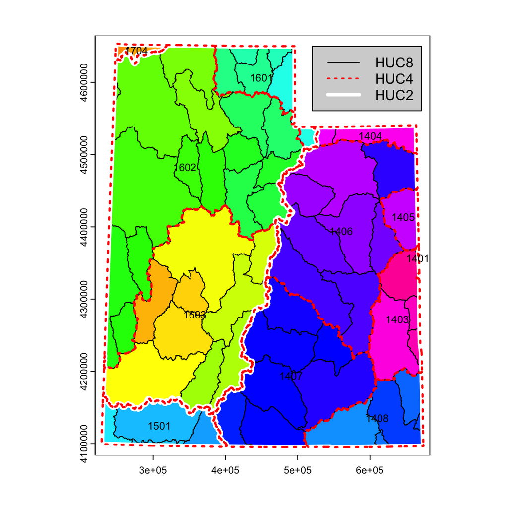

```r
# Setting parameters
par(mar = c(2,2,2,8))

# Creating HUC4 and HUC2 by copying the UT vector
HUC4 <- UT_shape
HUC2 <- UT_shape

# Subtracting the last digits to create HUC4 and HUC2 vectors
HUC4$HUC <- substr(UT_shape$HUC,1,nchar(UT_shape$HUC) - 4)
HUC2$HUC <- substr(UT_shape$HUC,1,nchar(UT_shape$HUC) - 6)

# Aggregating by the same value for HUC2 and HUC4
HUC2 <- aggregate(HUC2,"HUC")
HUC4 <- aggregate(HUC4,"HUC")

# Plot UT_shape with HUC attribute
plot(UT_shape, "HUC", legend = FALSE)
plot(HUC2, "HUC", add = TRUE, col = "transparent", border = "white", legend = FALSE, lwd = 6, lty = 1)
plot(HUC4, "HUC", add = TRUE, col = "transparent", border = "red", legend = FALSE, lwd = 2.5, lty = 3)

# Create legend for HUC2 and HUC4
legend(x=520000,y=4650000, legend = c("HUC8","HUC4", "HUC2"), col = c("black","red", "white"), lty = c(1,3, 1), lwd = c(1,2, 4),bg = "lightgrey")
text(HUC4,"HUC",cex = 0.75)
```

# #9

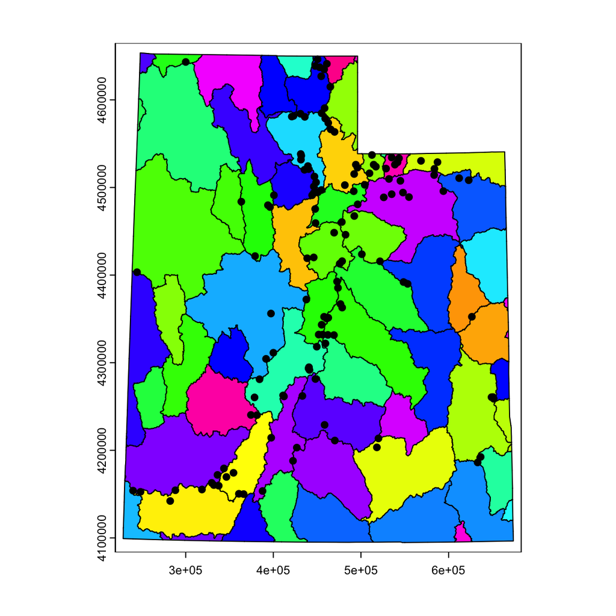

```r
# Adding coordinate system to full snotel data vector
crs(vect_full) <- "epsg:4269"

# Re-projecting to the same coordinate system as HUC8 data
vect_full <- project(vect_full,UT_shape)

# Plotting
plot(UT_shape,"NAME",legend=F)
plot(vect_full,add=T)
```

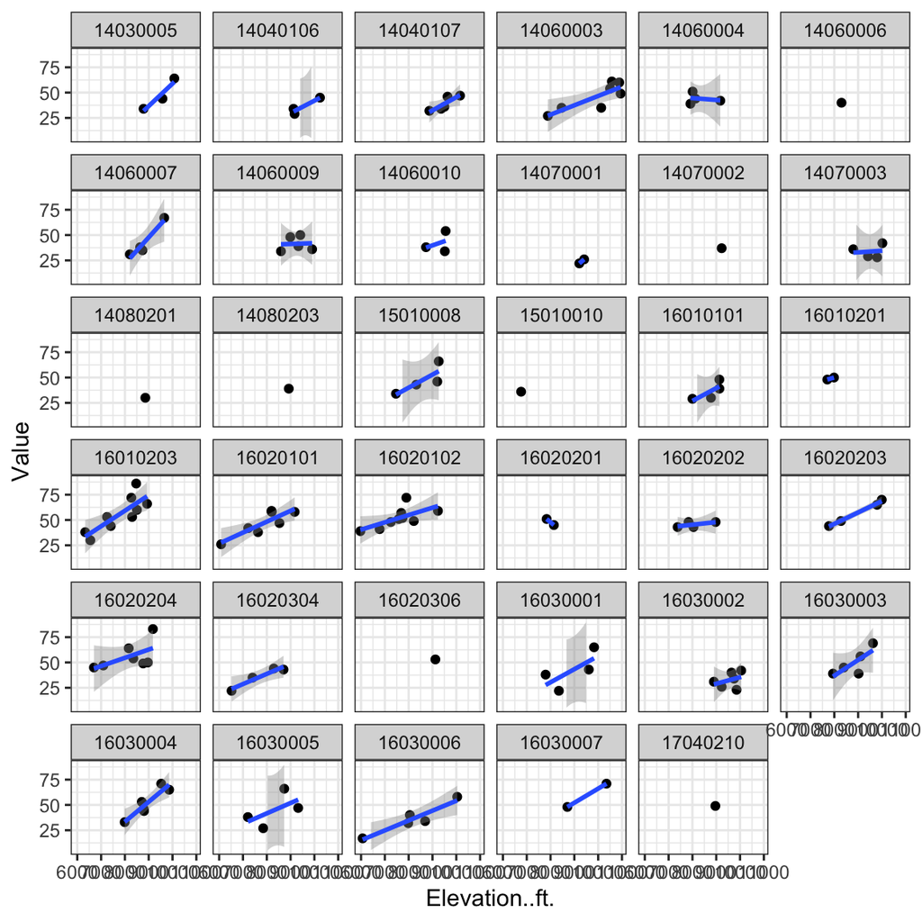

```r
# Creating new vector that has both UT_shape and vect_full data
intersected <- intersect(UT_shape,vect_full)

# Turning into data frame
intersect_df <- as.data.frame(intersected)

# Plotting each sheds snow depth by elevation plots
intersect_df %>%
  filter(Value != 0) %>%
  ggplot(aes(x = Elevation..ft., y = Value)) +
  geom_point() +
  geom_smooth(method = "lm") +
  ylim(5, 90) +
  facet_wrap(~ HUC) +
  theme_bw()
```

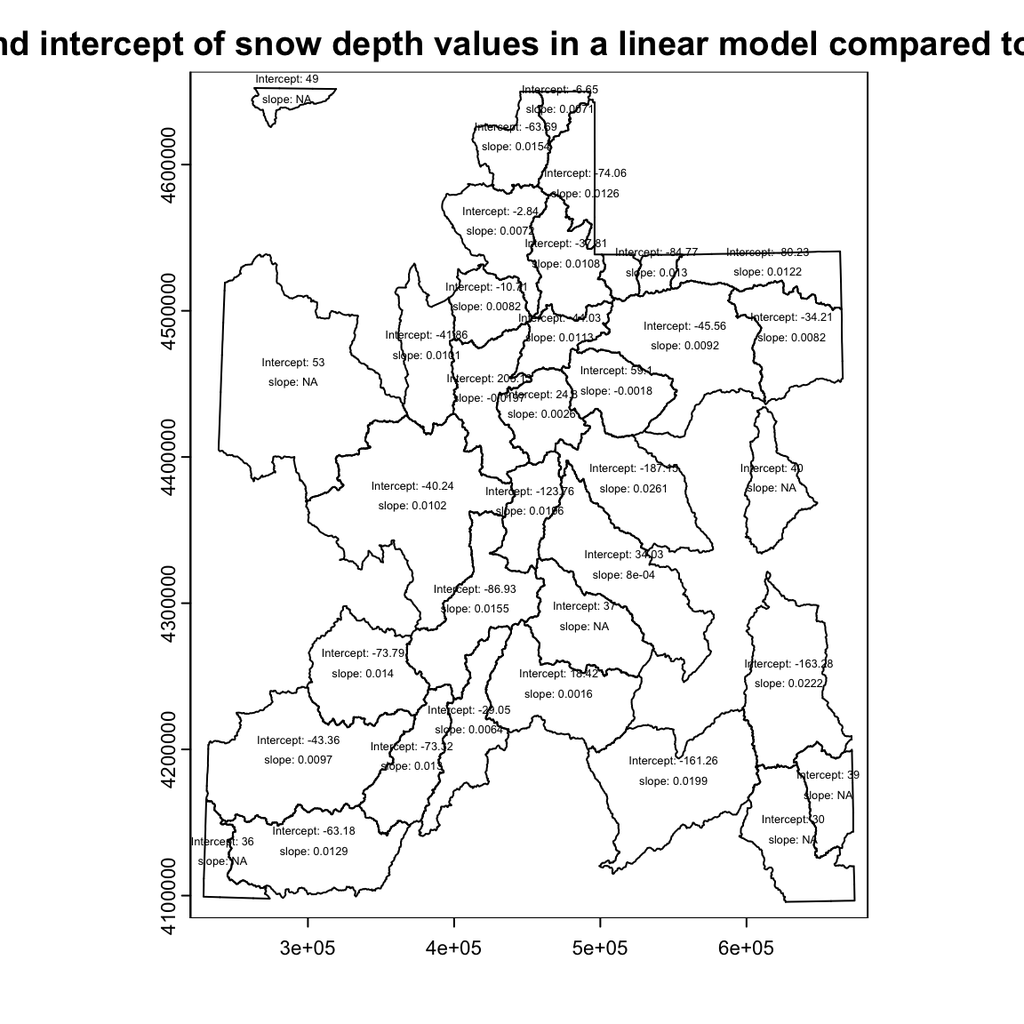

```r
# Filtering out 0 and NA
intersect_df <- intersect_df %>%
  filter(Value!= 0 & is.na(Value) == FALSE)

# Creating list of models for each HUC
models <- intersect_df %>%
  group_by(HUC) %>%
  do(model = lm(formula = Value~Elevation..ft., data = .))


# I had chatgpt help me with this, I wanted to make it so I could create the plot
# Initialize an empty data frame to store results
coefficients_df <- data.frame(HUC = character(), Intercept = numeric(), Elevation_Coefficient = numeric())

# Loop over each model
for (i in seq_along(models$model)) {
  # Extract coefficients from the current model
  coef_values <- coef(models$model[[i]])

  # Extract HUC value
  huc_value <- models$HUC[i]

  # Append coefficients to the data frame
  coefficients_df <- bind_rows(coefficients_df, data.frame(HUC = huc_value,
                                                           Intercept = coef_values[1],
                                                           Elevation_Coefficient = coef_values[2]))
}

# Convert HUC column in coefficients_df to character
coefficients_df$HUC <- as.character(coefficients_df$HUC)

# Merge the coefficients data frame with the UT_shape vector data
merged_data <- merge(UT_shape, coefficients_df, by = "HUC")

# Rounding data
merged_data$Elevation_Coefficient <- round(merged_data$Elevation_Coefficient,4)
merged_data$Intercept <- round(merged_data$Intercept,2)

# Plot merged_data
plot(merged_data, legend = FALSE,main = "Slope and intercept of snow depth values in a linear model compared to elevation")
text(merged_data, labels = paste("slope:", merged_data$Elevation_Coefficient), cex = 0.4)
text(merged_data, labels = paste("Intercept:", merged_data$Intercept), cex = 0.4,pos = 3)
```

```r
# Looking at linear model for all of the HUC's combined
intersect_df %>%
  lm(formula = Value~Elevation..ft.)
```

```
##
## Call:
## lm(formula = Value ~ Elevation..ft., data = .)
##
## Coefficients:
##    (Intercept)  Elevation..ft.
##      15.131302        0.003465
```

Looking at the results across all of the available watersheds it definitely shows a correlation with higher slopes in areas that should have a higher elevation. Most of the slopes for each of the watersheds are higher than the overall linear model, this makes sense because some of the watersheds actually have a negative slope and that would affect the linear model quite a bit.

# #10

```r
HUCs <- unique(intersect_df$HUC)

# Initialize an empty list to store subsets
subset_list <- list()

# Creating empty dataframe
huc_data <- data.frame(
  HUC = character(),
  Station_Count = integer(),
  Max_Snow_Depth = numeric(),
  Mean_Elevation = numeric()
)

# Loop over each unique HUC value
for (i in unique(intersect_df$HUC)) {
  # Create a subset of intersect_df for the current HUC
  subset_df <- intersect_df[intersect_df$HUC == i, ]

    cat(paste0("Number of stations for HUC ", i, ": ",nrow(subset_df),"\n"))
    cat(paste0("Max snow depth for HUC ", i, ": ",max(subset_df$Value),"\n"))
    cat(paste0("Mean elevation for HUC ",i,": ",round(mean(subset_df$Elevation..ft.),2),"\n","\n"))

     # Calculate the number of stations
    station_count <- nrow(subset_df)

    # Calculate the max snow depth
    max_snow_depth <- max(subset_df$Value)

    # Calculate the mean elevation
    mean_elevation <- round(mean(subset_df$Elevation..ft.), 2)

    # Add a row to the data frame
    huc_data <- rbind(huc_data, data.frame(HUC = i, Station_Count = station_count, Max_Snow_Depth = max_snow_depth, Mean_Elevation = mean_elevation))
}
```

```
## Number of stations for HUC 16010101: 4
## Max snow depth for HUC 16010101: 48
## Mean elevation for HUC 16010101: 8760
##
## Number of stations for HUC 16010203: 9
## Max snow depth for HUC 16010203: 86
## Mean elevation for HUC 16010203: 7779.89
##
## Number of stations for HUC 14060006: 1
## Max snow depth for HUC 14060006: 40
## Mean elevation for HUC 14060006: 8302
##
## Number of stations for HUC 17040210: 1
## Max snow depth for HUC 17040210: 49
## Mean elevation for HUC 17040210: 8964
##
## Number of stations for HUC 16020201: 2
## Max snow depth for HUC 16020201: 51
## Mean elevation for HUC 16020201: 7987.5
##
## Number of stations for HUC 14070001: 2
## Max snow depth for HUC 14070001: 26
## Mean elevation for HUC 14070001: 9309.5
##
## Number of stations for HUC 16030002: 6
## Max snow depth for HUC 16030002: 42
## Mean elevation for HUC 16030002: 9569.83
##
## Number of stations for HUC 14040106: 3
## Max snow depth for HUC 14040106: 45
## Mean elevation for HUC 14040106: 9508.33
##
## Number of stations for HUC 16020304: 4
## Max snow depth for HUC 16020304: 44
## Mean elevation for HUC 16020304: 7730
##
## Number of stations for HUC 16020202: 4
## Max snow depth for HUC 16020202: 48
## Mean elevation for HUC 16020202: 8058.25
##
```

[output cut: 84 more lines]

```
## Number of stations for HUC 14060010: 3
## Max snow depth for HUC 14060010: 54
## Mean elevation for HUC 14060010: 9266.33
##
## Number of stations for HUC 16010201: 2
## Max snow depth for HUC 16010201: 50
## Mean elevation for HUC 16010201: 7846
##
## Number of stations for HUC 16020203: 4
## Max snow depth for HUC 16020203: 70
## Mean elevation for HUC 16020203: 8960.5
##
## Number of stations for HUC 16030004: 6
## Max snow depth for HUC 16030004: 71
## Mean elevation for HUC 16030004: 8944.83
```

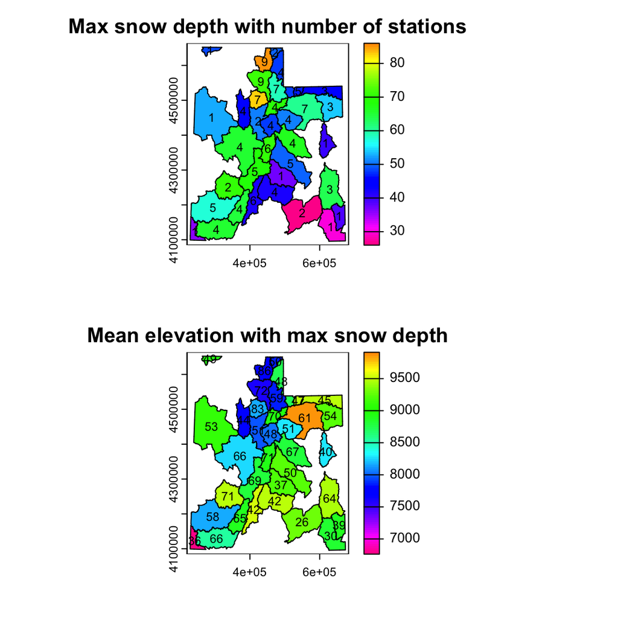

```r
# Merging the data for the final plot
huc_final <- merge(UT_shape,huc_data)

# Setting columns and rows
par(mfrow= c(2,1), mar = c(5,4,2,2))

# Plotting
plot(huc_final,"Max_Snow_Depth",type="continuous", main = "Max snow depth with number of stations", cex = 0.2)
text(huc_final,"Station_Count", cex = 0.7)
plot(huc_final,"Mean_Elevation",type="continuous",main = "Mean elevation with max snow depth", cex = 0.2)
text(huc_final,"Max_Snow_Depth",cex = 0.7)
```